# Reproducible Reporting using Markdown - R/RStudio

Meta Miriam Bönniger

27 Juli, 2021

```r
knitr::opts_chunk$set(echo = TRUE)
```

# Basic markdown script

Tasks:

1. Try to create the Markdown script for this html output (you are welcome to copy the r code).
2. This Markdown is still very confusing. Try to make this Markdown script clearer (example: Reproducible-Reporting-using-Markdown-R/RStudio_advancedMarkdown.html)
   - hide code
   - create a table of content that links to the sections
   - delete the hashtags at the beginning of the output of the “Variable Types”, the “Simple Linear Regression” and the Reference section
   - reduce histograms from “Visualize Data” section to 50% width and place them next to each other
   - reduce simple linear regression plots to 70% width
   - create a results table for the multiple regression including N, confidence interval and r-squared values

## Setup

### Load packages

```r
list.of.packages <- c("patchwork", "ggpubr", "tidyverse", "data.table", "knitr", "markdown", "rmarkdown", "dplyr", "ggplot2", "moments", "car", "tableone")

# install packages if new
new.packages <- list.of.packages[!(list.of.packages %in% installed.packages()[,"Package"])]
if(length(new.packages)) install.packages(new.packages)

# load packages
invisible(lapply(list.of.packages, library, character.only = TRUE))
```

### Download OASIS dataset

We’ll be downloading the data from http://www.oasis-brains.org/pdf/oasis_longitudinal.csv

A full explanation of the data can be found in:

*Open Access Series of Imaging Studies (OASIS): Longitudinal MRI Data in Nondemented and Demented Older Adults.* *Marcus, DS, Fotenos, AF, Csernansky, JG, Morris, JC, Buckner, RL, 2010. Journal of Cognitive Neuroscience, 22, 2677-2684. doi: 10.1162/jocn.2009.21407*

```r
df <- read.csv("http://www.oasis-brains.org/pdf/oasis_longitudinal.csv")

# print out top 5 rows of the DataFrame
kable(head(df, n = 5L)) #if the package kable is not found change it to knitr::kable
```

| Subject.ID | MRI.ID | Group | Visit | MR.Delay | M.F | Hand | Age | EDUC | SES | MMSE | CDR | eTIV | nWBV | ASF |
| --- | --- | --- | --- | --- | --- | --- | --- | --- | --- | --- | --- | --- | --- | --- |
| OAS2_0001 | OAS2_0001_MR1 | Nondemented | 1 | 0 | M | R | 87 | 14 | 2 | 27 | 0.0 | 1987 | 0.696 | 0.883 |
| OAS2_0001 | OAS2_0001_MR2 | Nondemented | 2 | 457 | M | R | 88 | 14 | 2 | 30 | 0.0 | 2004 | 0.681 | 0.876 |
| OAS2_0002 | OAS2_0002_MR1 | Demented | 1 | 0 | M | R | 75 | 12 | NA | 23 | 0.5 | 1678 | 0.736 | 1.046 |
| OAS2_0002 | OAS2_0002_MR2 | Demented | 2 | 560 | M | R | 76 | 12 | NA | 28 | 0.5 | 1738 | 0.713 | 1.010 |
| OAS2_0002 | OAS2_0002_MR3 | Demented | 3 | 1895 | M | R | 80 | 12 | NA | 22 | 0.5 | 1698 | 0.701 | 1.034 |

## Pre-processing the Data

### Dementia status from CDR

We’re told in the associated paper (linked above) that the CDR values correspond to the following levels of severity:

- 0 = no dementia
- 0.5 = very mild AD
- 1 = mild AD
- 2 = moderate AD

So let’s derive this “Status” from the CDR values:

```r
#create an ordered factor and map CDR values to status
df <- df %>%
  #leave numeric version for later
  dplyr::mutate(CDR.num = CDR) %>%
  #Normally, mutate works iteratively within a command. However, I have experienced situations
  #where the newly created variables could not be reused in the same mutate, so here is a second mutate function.
  dplyr::mutate(CDR = dplyr::case_when(CDR.num == 0 ~ 'no dementia',
                                       CDR.num == 0.5 ~ 'very mild AD',
                                       CDR.num == 1 ~ 'mild AD',
                                       CDR.num == 2 ~ 'moderate AD'), # if no cases match NA is returned
                CDR = forcats::fct_reorder(CDR, CDR.num))
```

Now we can look at this status, and how many records there are both overall, and at each of the visits (or time points).

```r
# Let's look at how many records we have of each severity
kable(df %>%
        dplyr::group_by(CDR) %>%
        dplyr::tally())
```

| CDR | n |
| --- | --- |
| no dementia | 206 |
| very mild AD | 123 |
| mild AD | 41 |
| moderate AD | 3 |

```r
# How many of each status do we have at each visit?
kable(df %>%
        dplyr::group_by(Visit,CDR) %>%
        dplyr::tally())
```

| Visit | CDR | n |
| --- | --- | --- |
| 1 | no dementia | 85 |
| 1 | very mild AD | 52 |
| 1 | mild AD | 13 |
| 2 | no dementia | 73 |
| 2 | very mild AD | 49 |
| 2 | mild AD | 19 |
| 2 | moderate AD | 3 |
| 3 | no dementia | 34 |
| 3 | very mild AD | 18 |
| 3 | mild AD | 6 |
| 4 | no dementia | 10 |
| 4 | very mild AD | 3 |
| 4 | mild AD | 2 |
| 5 | no dementia | 4 |
| 5 | very mild AD | 1 |
| 5 | mild AD | 1 |

### Variable Types

```r
str(df)
```

```
## 'data.frame':    373 obs. of  16 variables:
##  $ Subject.ID: Factor w/ 150 levels "OAS2_0001","OAS2_0002",..: 1 1 2 2 2 3 3 4 4 4 ...
##  $ MRI.ID    : Factor w/ 373 levels "OAS2_0001_MR1",..: 1 2 3 4 5 6 7 8 9 10 ...
##  $ Group     : Factor w/ 3 levels "Converted","Demented",..: 3 3 2 2 2 3 3 3 3 3 ...
##  $ Visit     : int  1 2 1 2 3 1 2 1 2 3 ...
##  $ MR.Delay  : int  0 457 0 560 1895 0 538 0 1010 1603 ...
##  $ M.F       : Factor w/ 2 levels "F","M": 2 2 2 2 2 1 1 2 2 2 ...
##  $ Hand      : Factor w/ 1 level "R": 1 1 1 1 1 1 1 1 1 1 ...
##  $ Age       : int  87 88 75 76 80 88 90 80 83 85 ...
##  $ EDUC      : int  14 14 12 12 12 18 18 12 12 12 ...
##  $ SES       : int  2 2 NA NA NA 3 3 4 4 4 ...
##  $ MMSE      : int  27 30 23 28 22 28 27 28 29 30 ...
##  $ CDR       : Factor w/ 4 levels "no dementia",..: 1 1 2 2 2 1 1 1 2 1 ...
##  $ eTIV      : int  1987 2004 1678 1738 1698 1215 1200 1689 1701 1699 ...
##  $ nWBV      : num  0.696 0.681 0.736 0.713 0.701 0.71 0.718 0.712 0.711 0.705 ...
##  $ ASF       : num  0.883 0.876 1.046 1.01 1.034 ...
##  $ CDR.num   : num  0 0 0.5 0.5 0.5 0 0 0 0.5 0 ...
```

Change variable names

```r
df <- df %>%
  dplyr::rename(Sex = M.F,
                Education = EDUC)
```

**Coerche types? Not always needed but good practice.**

Change “Visit” from numeric values to ordered factor (1-5).

```r
df <- df %>%
  dplyr::mutate(Visit = factor(Visit,
                               levels=c(1,2,3,4,5),
                               ordered=TRUE))
```

Change “SES” from numeric values to ordered factor (1 = highest to 5 = lowest status).

```r
df <- df %>%
  dplyr::mutate(SES = factor(SES,
                             levels=c(1,2,3,4,5),
                             ordered=TRUE))
```

### Visits & Baseline Data

```r
kable(df %>%
        dplyr::group_by(Visit) %>%
        dplyr::tally(),
      caption = "Participant number per visit")
```

Participant number per visit

| Visit | n |
| --- | --- |
| 1 | 150 |
| 2 | 144 |
| 3 | 58 |
| 4 | 15 |
| 5 | 6 |

Filter for baseline data, and look at their dementia status on arrival

```r
df_baseline <- df %>%
  dplyr::filter(Visit == 1)

kable(df_baseline %>%
        dplyr::group_by(CDR) %>%
        dplyr::tally(),
      caption = "CDR status of participants in first visit")
```

CDR status of participants in first visit

| CDR | n |
| --- | --- |
| no dementia | 85 |
| very mild AD | 52 |
| mild AD | 13 |

## Data Exploration

### Summarise Data (Non-numerical Variables)

With the exception of CDR, as this has already been done above.

```r
numeric.var <- df %>%
  dplyr::select(where(is.numeric), -CDR.num) %>%
  names()

kable(head(df %>%
             dplyr::select(-all_of(numeric.var))) %>%
        data.frame(),
      caption = "Head of all non-numeric variables in the dataset.")
```

Head of all non-numeric variables in the dataset.

| Subject.ID | MRI.ID | Group | Visit | Sex | Hand | SES | CDR | CDR.num |
| --- | --- | --- | --- | --- | --- | --- | --- | --- |
| OAS2_0001 | OAS2_0001_MR1 | Nondemented | 1 | M | R | 2 | no dementia | 0.0 |
| OAS2_0001 | OAS2_0001_MR2 | Nondemented | 2 | M | R | 2 | no dementia | 0.0 |
| OAS2_0002 | OAS2_0002_MR1 | Demented | 1 | M | R | NA | very mild AD | 0.5 |
| OAS2_0002 | OAS2_0002_MR2 | Demented | 2 | M | R | NA | very mild AD | 0.5 |
| OAS2_0002 | OAS2_0002_MR3 | Demented | 3 | M | R | NA | very mild AD | 0.5 |
| OAS2_0004 | OAS2_0004_MR1 | Nondemented | 1 | F | R | 3 | no dementia | 0.0 |

```r
kable(df %>%
        dplyr::group_by(Group) %>%
        dplyr::tally(),
      caption = "Factor levels and frequency of variable 'Group'")
```

Factor levels and frequency of variable ‘Group’

| Group | n |
| --- | --- |
| Converted | 37 |
| Demented | 146 |
| Nondemented | 190 |

```r
kable(df %>%
        dplyr::group_by(Visit) %>%
        dplyr::tally(),
      caption = "Factor levels and frequency of variable 'Visit'")
```

Factor levels and frequency of variable ‘Visit’

| Visit | n |
| --- | --- |
| 1 | 150 |
| 2 | 144 |
| 3 | 58 |
| 4 | 15 |
| 5 | 6 |

```r
kable(df %>%
        dplyr::group_by(Sex) %>%
        dplyr::tally(),
      caption = "Factor levels and frequency of variable 'Sex'")
```

Factor levels and frequency of variable ‘Sex’

| Sex | n |
| --- | --- |
| F | 213 |
| M | 160 |

```r
kable(df %>%
        dplyr::group_by(Hand) %>%
        dplyr::tally(),
      caption = "Factor levels and frequency of variable 'Hand'")
```

Factor levels and frequency of variable ‘Hand’

| Hand | n |
| --- | --- |
| R | 373 |

```r
kable(df %>%
        dplyr::group_by(SES) %>%
        dplyr::tally(),
      caption = "Factor levels and frequency of variable 'SES'")
```

Factor levels and frequency of variable ‘SES’

| SES | n |
| --- | --- |
| 1 | 88 |
| 2 | 103 |
| 3 | 82 |
| 4 | 74 |
| 5 | 7 |
| NA | 19 |

### Summarise Data (Numerical Variables)

```r
kable(df %>%
        dplyr::select(all_of(numeric.var)) %>%
        summary() %>%
        data.frame() %>%
        dplyr::select(-Var1) %>%
        dplyr::rename(Variable = Var2) %>%
        dplyr::mutate(Freq = gsub(" ", "", Freq, fixed = TRUE),
                      Freq = gsub("\'", "", Freq, fixed = TRUE)) %>%
        dplyr::filter(!is.na(Freq)) %>%
        tidyr::separate(Freq, c("V1", "V2"), sep= ":") %>%
        dplyr::group_by(Variable) %>%
        tidyr::spread(V1, V2),
      caption = "Summary of all numeric variables in the dataset")
```

Summary of all numeric variables in the dataset

| Variable | 1stQu. | 3rdQu. | Max. | Mean | Median | Min. | NAs |
| --- | --- | --- | --- | --- | --- | --- | --- |
| MR.Delay | 0.0 | 873.0 | 2639.0 | 595.1 | 552.0 | 0.0 | NA |
| Age | 71.00 | 82.00 | 98.00 | 77.01 | 77.00 | 60.00 | NA |
| Education | 12.0 | 16.0 | 23.0 | 14.6 | 15.0 | 6.0 | NA |
| MMSE | 27.00 | 30.00 | 30.00 | 27.34 | 29.00 | 4.00 | 2 |
| eTIV | 1357 | 1597 | 2004 | 1488 | 1470 | 1106 | NA |
| nWBV | 0.7000 | 0.7560 | 0.8370 | 0.7296 | 0.7290 | 0.6440 | NA |
| ASF | 1.099 | 1.293 | 1.587 | 1.195 | 1.194 | 0.876 | NA |

### Visualize Data (numerical variables)

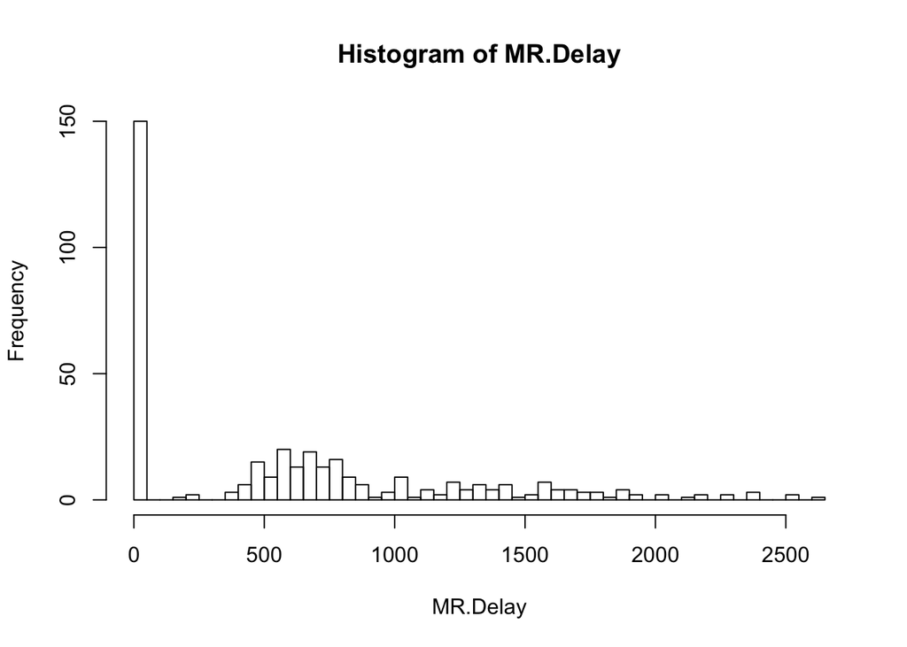

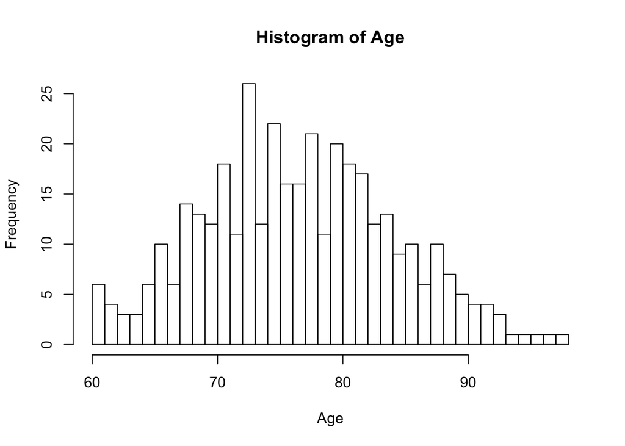

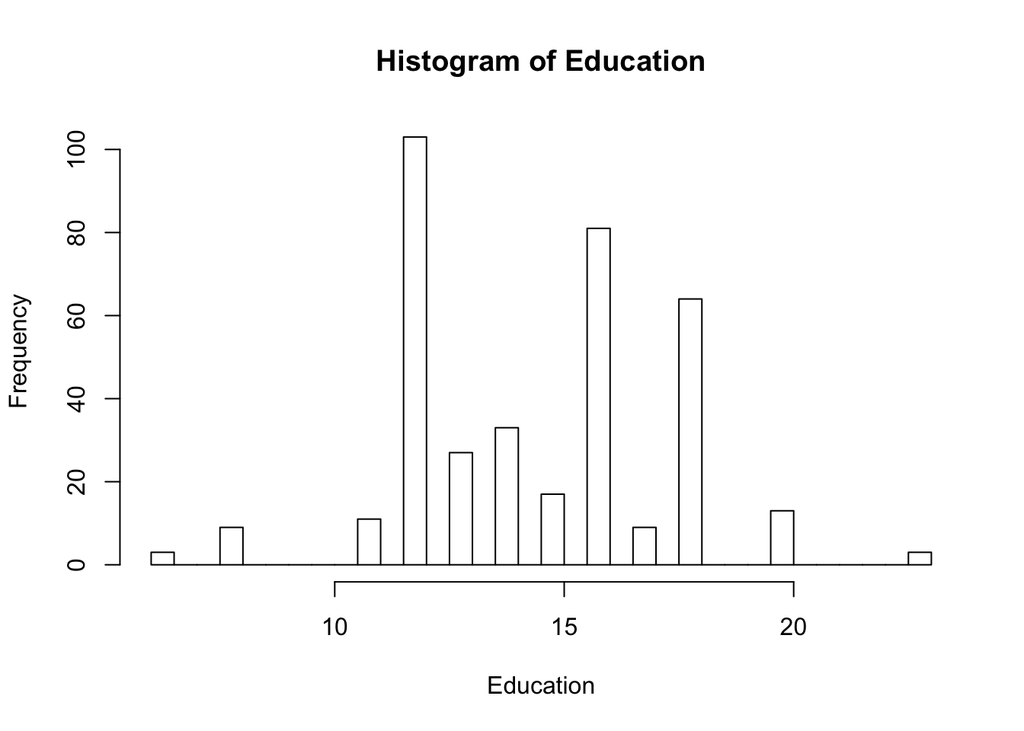

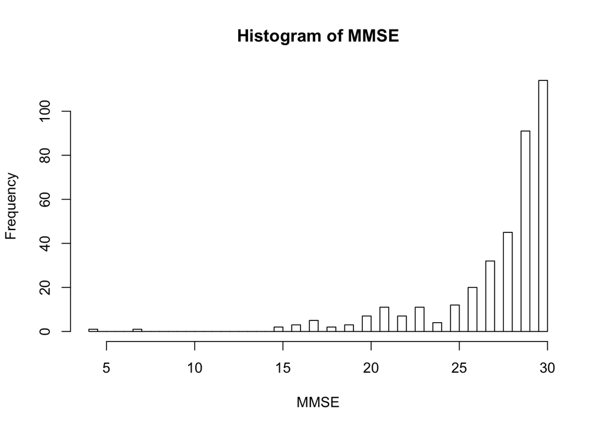

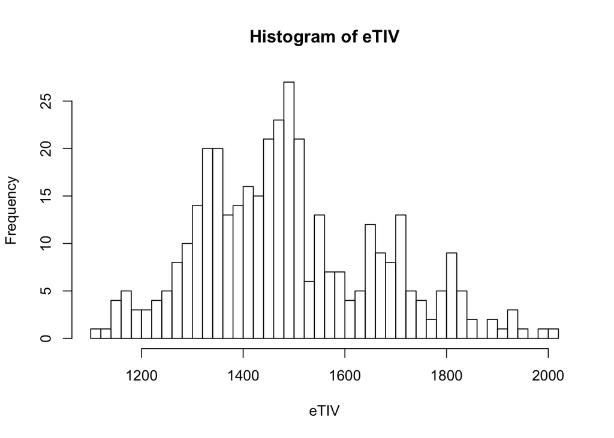

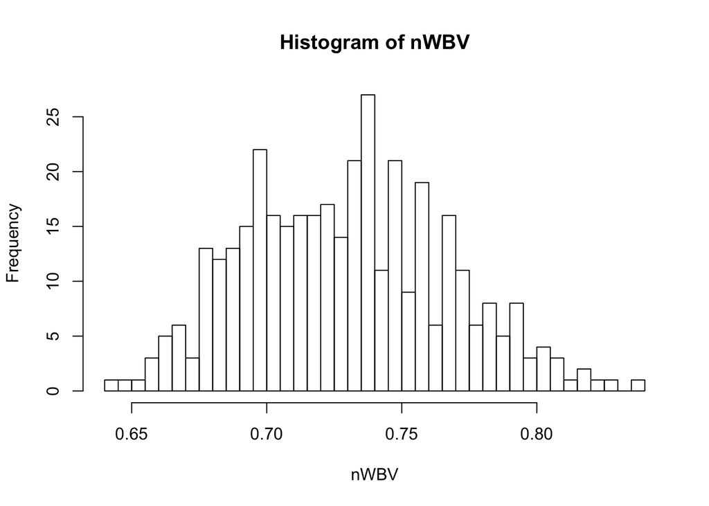

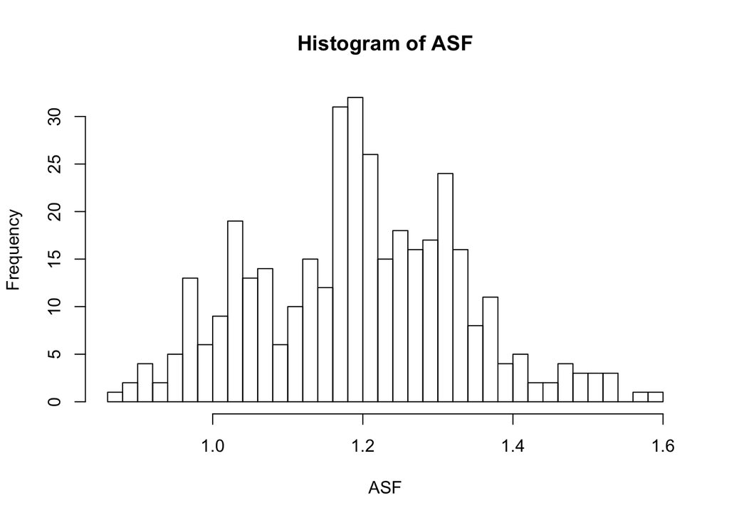

```r
#distribution
distribution_plots <- function(variable) {
  df.plot <- df %>%
    dplyr::filter(!is.na(.[[variable]]))

  hist(df.plot[[variable]],
       breaks = 50,
       xlab = paste0(variable),
       main = paste0("Histogram of ", variable))
}

invisible(lapply(numeric.var, distribution_plots))
```

```r
rm(distribution_plots)
```

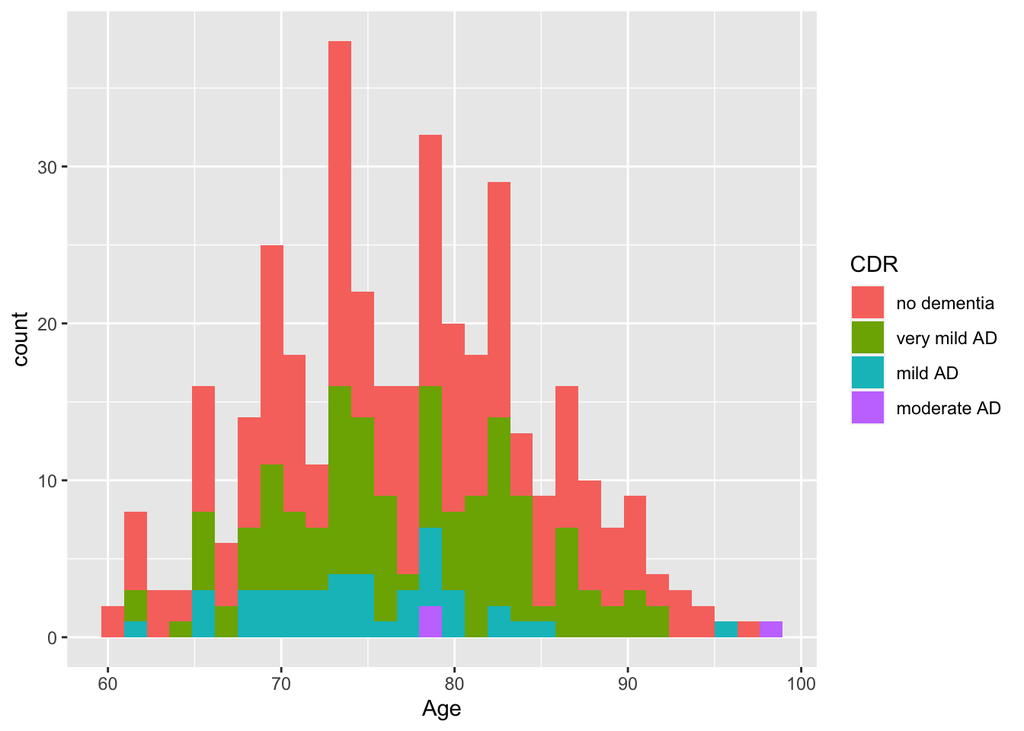

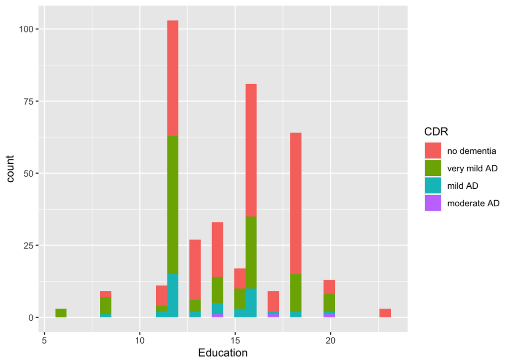

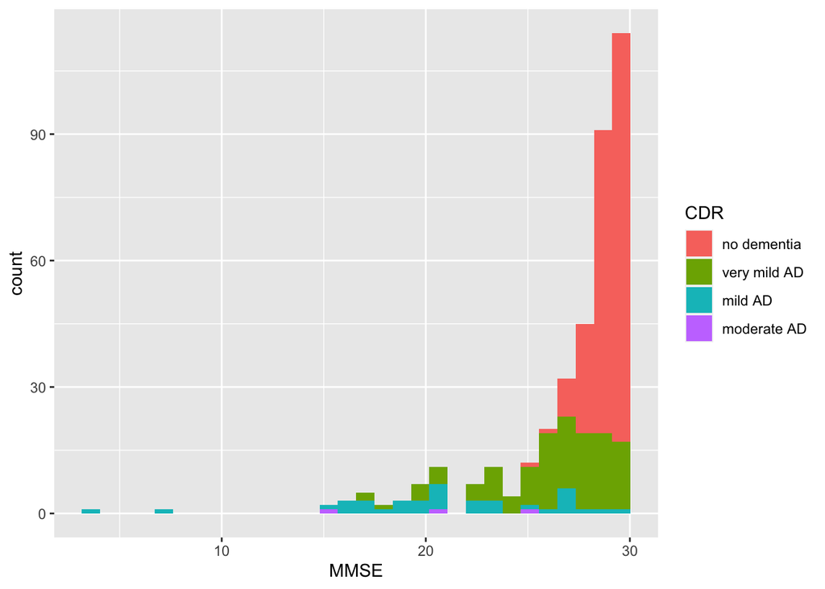

```r
numeric.var <- c("Age", "Education", "MMSE")
#distribution
distribution_plots <- function(variable) {
  df.plot <- df %>%
    dplyr::filter(!is.na(.[[variable]]))

  plot <- ggplot(data = df.plot,
                 aes_(x = as.name(variable), fill = ~ CDR)) +
    geom_histogram()
  print(plot)
}

invisible(lapply(numeric.var, distribution_plots))
```

```r
rm(numeric.var)
rm(distribution_plots)
```

## Sample Analysis: Table 1

Create a typical table one. Show it in this Markdown and save it also as csv for integrating it, for example, into a manuscript.

```r
# 1. Select variables for table
myVars <- names(df %>%
                  dplyr::select(-Subject.ID, -MRI.ID, -CDR.num))


# 2. Make a list of all categorical variables from the myVars list for this table
catVars <- df %>%
  dplyr::select(all_of(myVars)) %>%
  dplyr::select_if(purrr::negate(is.numeric)) %>%
  names()

# 3. Check visually for non-normally distributed numerical variables
#hist() or histograms
nonnormaldist <- c("MR.Delay", "MMSE")

# 4. Create dataset for table 1
table1df <- df %>%
  dplyr::select(all_of(myVars))

# 5. Create table
tab1 <- tableone::CreateTableOne(data = table1df,
                                 vars = myVars,
                                 factorVars = catVars)

# 6. Modify list of table to get a data frame
tab2 <- print(tab1,
              showAllLevels = TRUE,
              printToggle = FALSE,
              noSpaces = TRUE,
              explain = FALSE,
              test = TRUE,
              contDigits = 1,
              catDigits = 1,
              missing = TRUE,
              nonnormal = nonnormaldist) %>%
  as.data.frame() %>%
  data.table::setDT(., keep.rownames = TRUE)
#summary(tab1) #gives more information regarding missing values

# 7. Rename column and rownames (of rn) to create a nice table that can be used in a manuscript
tab3 <- tab2 %>%
  dplyr::mutate(
    rn = ifelse(grepl("^X", rn), "", rn)) %>%
  dplyr::mutate(
    rn = dplyr::recode(rn,
                       "Group" = "Group, N (%)",
                       "Visit" = "Number of participants per visit, N (%)",
                       "MR.Delay" = "Time delay for MR imaging, median [IQR]",
                       "Sex" = "Sex, N (%)",
                       "Hand" = "Handedness, N (%)",
                       "Age" = "Age (years), M (SD)",
                       "Education" = "Education (years), M (SD)",
                       "SES" = "Socioeconomic status, N (%)",
                       "MMSE" = "Mini mental state examination, median [IQR]",
                       "CDR" = "Clinical Dementia Rating, N (%)",
                       "eTIV" = "Estimated total intracranial volume (cm3), M (SD)",
                       "nWBV" = "Normalized whole-brain volume, M (SD)",
                       "ASF" = "Atlas scaling factor, M (SD)"),
    level = dplyr::recode(level,
                          "F" = "women",
                          "M" = "men",
                          "R" = "right")) %>%
  dplyr::rename("Characteristic" = "rn")

# 8. Print table in markdown
kable(tab3)
```

| Characteristic | level | Overall | Missing |
| --- | --- | --- | --- |
| n |  | 373 |  |
| Group, N (%) | Converted | 37 (9.9) | 0.0 |
|  | Demented | 146 (39.1) |  |
|  | Nondemented | 190 (50.9) |  |
| Number of participants per visit, N (%) | 1 | 150 (40.2) | 0.0 |
|  | 2 | 144 (38.6) |  |
|  | 3 | 58 (15.5) |  |
|  | 4 | 15 (4.0) |  |
|  | 5 | 6 (1.6) |  |
| Time delay for MR imaging, median [IQR] |  | 552.0 [0.0, 873.0] | 0.0 |
| Sex, N (%) | women | 213 (57.1) | 0.0 |
|  | men | 160 (42.9) |  |
| Handedness, N (%) | right | 373 (100.0) | 0.0 |
| Age (years), M (SD) |  | 77.0 (7.6) | 0.0 |
| Education (years), M (SD) |  | 14.6 (2.9) | 0.0 |
| Socioeconomic status, N (%) | 1 | 88 (24.9) | 5.1 |
|  | 2 | 103 (29.1) |  |
|  | 3 | 82 (23.2) |  |
|  | 4 | 74 (20.9) |  |
|  | 5 | 7 (2.0) |  |
| Mini mental state examination, median [IQR] |  | 29.0 [27.0, 30.0] | 0.5 |
| Clinical Dementia Rating, N (%) | no dementia | 206 (55.2) | 0.0 |
|  | very mild AD | 123 (33.0) |  |
|  | mild AD | 41 (11.0) |  |
|  | moderate AD | 3 (0.8) |  |
| Estimated total intracranial volume (cm3), M (SD) |  | 1488.1 (176.1) | 0.0 |
| Normalized whole-brain volume, M (SD) |  | 0.7 (0.0) | 0.0 |
| Atlas scaling factor, M (SD) |  | 1.2 (0.1) | 0.0 |

```r
# 9. Save table for manuscript
write.csv(tab3, file = "Table_1.csv", row.names = FALSE)

rm(tab1); rm(tab2); rm(tab3); rm(table1df); rm(catVars); rm(myVars); rm(nonnormaldist)
```

## Data Analysis: MMSE Trajectories over Time

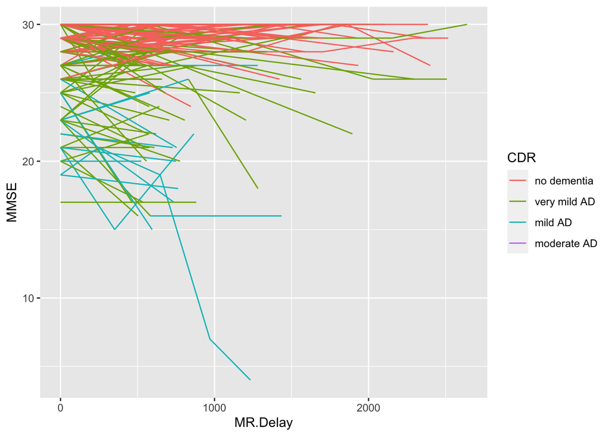

```r
df %>%
  dplyr::select(Subject.ID, MR.Delay, MMSE, CDR) %>%
  dplyr::filter(complete.cases(.)) %>%
  ggplot(aes(x = MR.Delay, y = MMSE, color = CDR, group = Subject.ID)) +
  geom_line()
```

## Data Analysis: Regression Analysis

### Simple Linear Regression

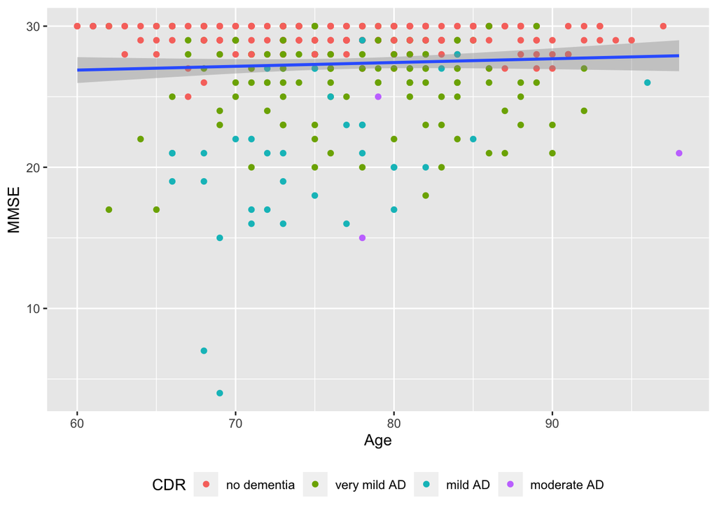

```
##
##
## |term        | estimate| std.error| statistic| p.value| conf.low| conf.high|   N| r.squared|
## |:-----------|--------:|---------:|---------:|-------:|--------:|---------:|---:|---------:|
## |(Intercept) |   25.283|     1.934|    13.072|   0.000|   21.480|    29.086| 371|     0.003|
## |Age         |    0.027|     0.025|     1.070|   0.285|   -0.022|     0.076| 371|     0.003|
```

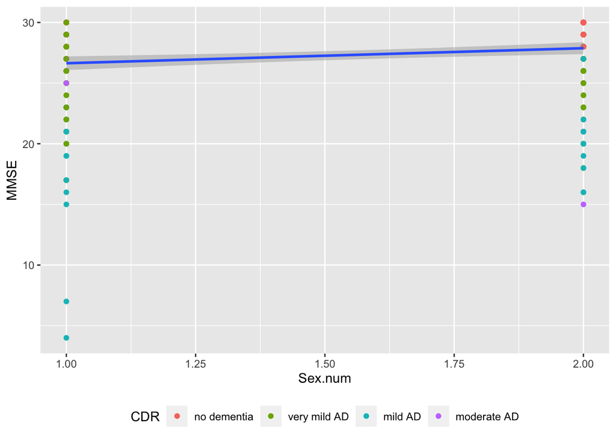

```
##
##
## |term        | estimate| std.error| statistic| p.value| conf.low| conf.high|   N| r.squared|
## |:-----------|--------:|---------:|---------:|-------:|--------:|---------:|---:|---------:|
## |(Intercept) |   25.398|     0.627|    40.500|   0.000|   24.165|    26.631| 371|     0.028|
## |Sex.num     |    1.239|     0.381|     3.251|   0.001|    0.490|     1.989| 371|     0.028|
```

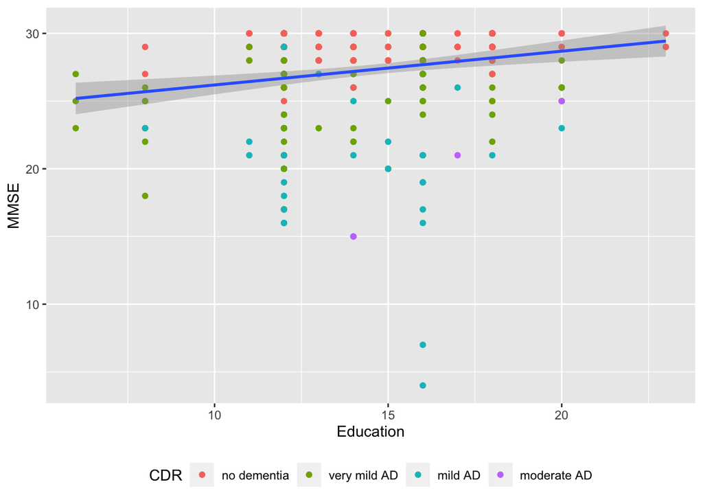

```
##
##
## |term        | estimate| std.error| statistic| p.value| conf.low| conf.high|   N| r.squared|
## |:-----------|--------:|---------:|---------:|-------:|--------:|---------:|---:|---------:|
## |(Intercept) |   23.698|     0.973|    24.350|       0|   21.784|    25.611| 371|     0.038|
## |Education   |    0.249|     0.065|     3.817|       0|    0.121|     0.378| 371|     0.038|
```

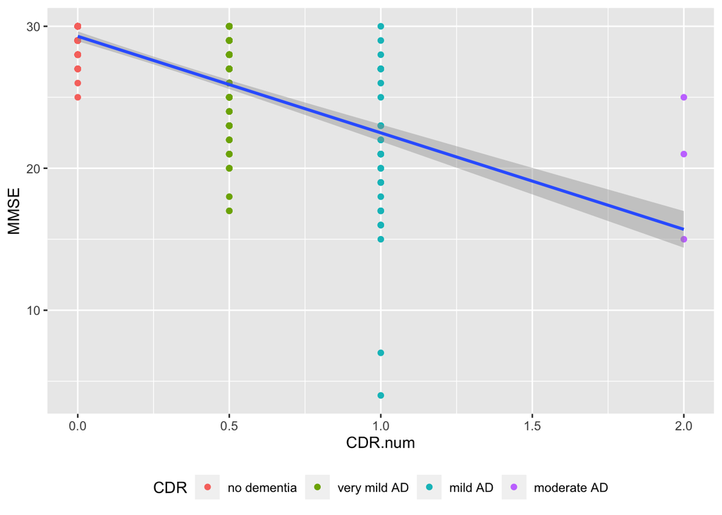

```
##
##
## |term        | estimate| std.error| statistic| p.value| conf.low| conf.high|   N| r.squared|
## |:-----------|--------:|---------:|---------:|-------:|--------:|---------:|---:|---------:|
## |(Intercept) |   29.294|     0.176|   166.473|       0|   28.948|    29.640| 371|     0.471|
## |CDR.num     |   -6.799|     0.375|   -18.137|       0|   -7.536|    -6.062| 371|     0.471|
```

```r
# To be able to create a multitude of plots with different y-axis values I created a function for the plots and used a loop (lapply) to create them.
# We have to add numeric sex and CDR variables to get regression lines in ggplot
df <- df %>%
  dplyr::mutate(Sex.num = ifelse(Sex == "M", 1,
                                 ifelse(Sex == "F", 2,
                                        NA)))

plotAgeAssociation <- function(xaxis) {
  # create complete cases dataset
  df.plot <- df %>%
    dplyr::select(MMSE, as.name(xaxis), CDR) %>%
    filter(complete.cases(.))

  print(ggplot(data=df.plot, aes_(x=as.name(xaxis), y=~MMSE)) +
          geom_point(aes_(color=~CDR)) +
          geom_smooth(method = lm) +
          theme(legend.position = "bottom"))
  regr <- lm(as.formula(paste0("MMSE ~ ", xaxis)),
             data = df.plot %>%
               # We recode CDR back as an unordered factor to have more interpretable results.
               dplyr::mutate(CDR = factor(CDR, ordered=FALSE)))
  result <- broom::tidy(regr, conf.int = TRUE, conf.level = 0.95)
  result$N <- regr$residuals %>% length()
  result$r.squared <- summary(regr)$r.squared
  result <- result %>%
    dplyr::mutate(across(where(is.numeric), round, 3))
  print(kable(result))

}

# run functions for education and MMSE on the y-axis
invisible(lapply(c("Age", "Sex.num", "Education", "CDR.num"), plotAgeAssociation))
```

```r
rm(plotAgeAssociation)
```

**Then we can do the same again, but this time stratify by the dementia status (not including CDR this time):**

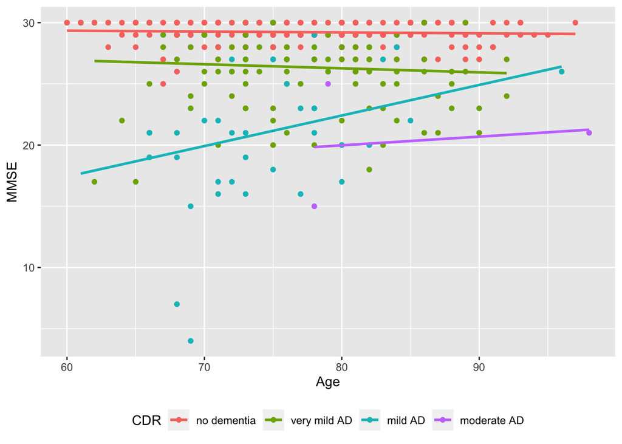

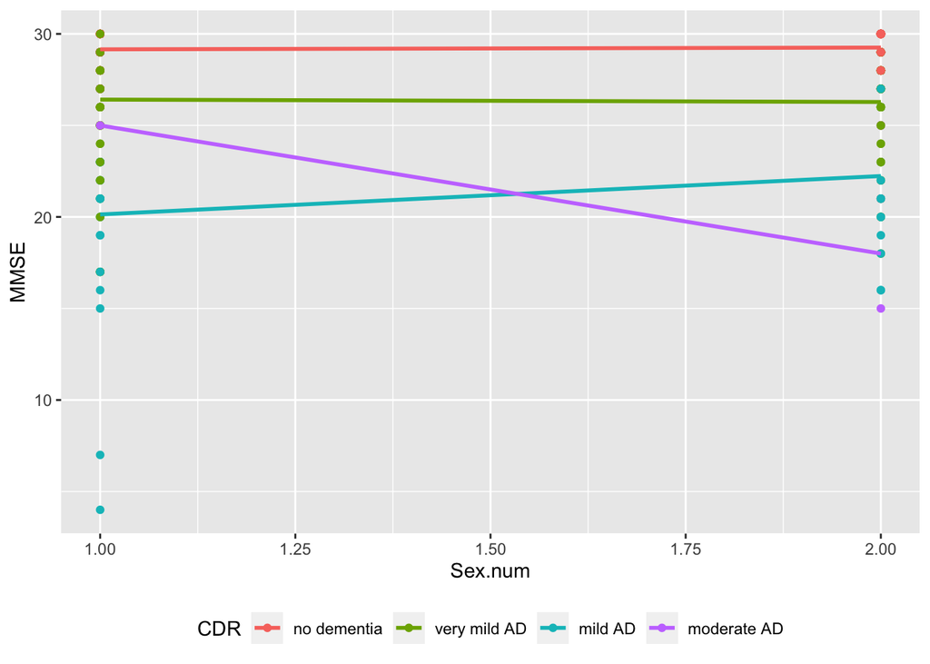

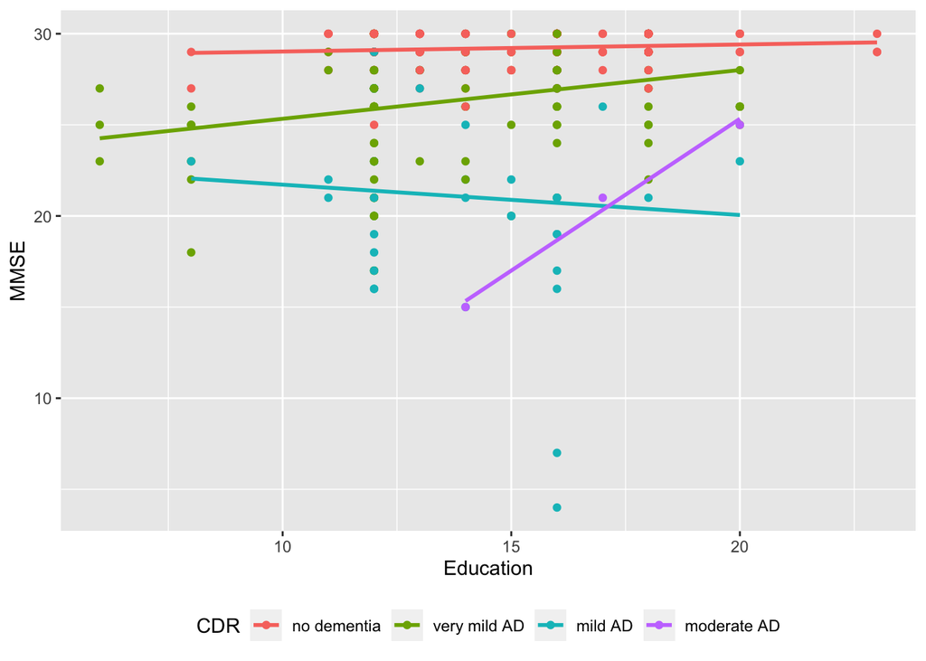

```r
plotAgeAssociation <- function(xaxis) {
  # create complete cases dataset
  df.plot <- df %>%
    dplyr::select(MMSE, as.name(xaxis), CDR) %>%
    dplyr::filter(complete.cases(.))

  print(ggplot(data=df.plot, aes_(x=as.name(xaxis), y=~MMSE, color=~CDR)) +
          geom_point() +
          geom_smooth(method = lm, se = FALSE) +
          theme(legend.position = "bottom"))
}

# run functions for education and MMSE on the y-axis
invisible(lapply(c("Age", "Sex.num", "Education"), plotAgeAssociation))
```

```r
rm(plotAgeAssociation)
```

### Multiple Linear Regression

We create a regression model with MMSE as the outcome and age, sex, education and CDR as the independents. Use the no dementia group as reference group for CDR.

```r
model <- lm(MMSE ~ Age + Sex + Education + relevel(factor(CDR, ordered=FALSE), ref = "no dementia"),
            data = df_baseline)
```

#### Assumption check

```r
kable(moments::skewness(model$residuals) %>%
        data.frame() %>%
        dplyr::rename("Skewness of residuals" = "."),
      caption = "Skewness of model residuals")
```

Skewness of model residuals

| Skewness of residuals |
| --- |
| -0.6230355 |

```r
kable(car::vif(model),
      caption = "Variance-inflation factors to assess multicolinearity of model independents")
```

Variance-inflation factors to assess multicolinearity of model independents

|  | GVIF | Df | GVIF^(1/(2*Df)) |
| --- | --- | --- | --- |
| Age | 1.013001 | 1 | 1.006480 |
| Sex | 1.096688 | 1 | 1.047228 |
| Education | 1.109618 | 1 | 1.053384 |
| relevel(factor(CDR, ordered = FALSE), ref = “no dementia”) | 1.180960 | 2 | 1.042459 |

Plots to check other regression model assumptions

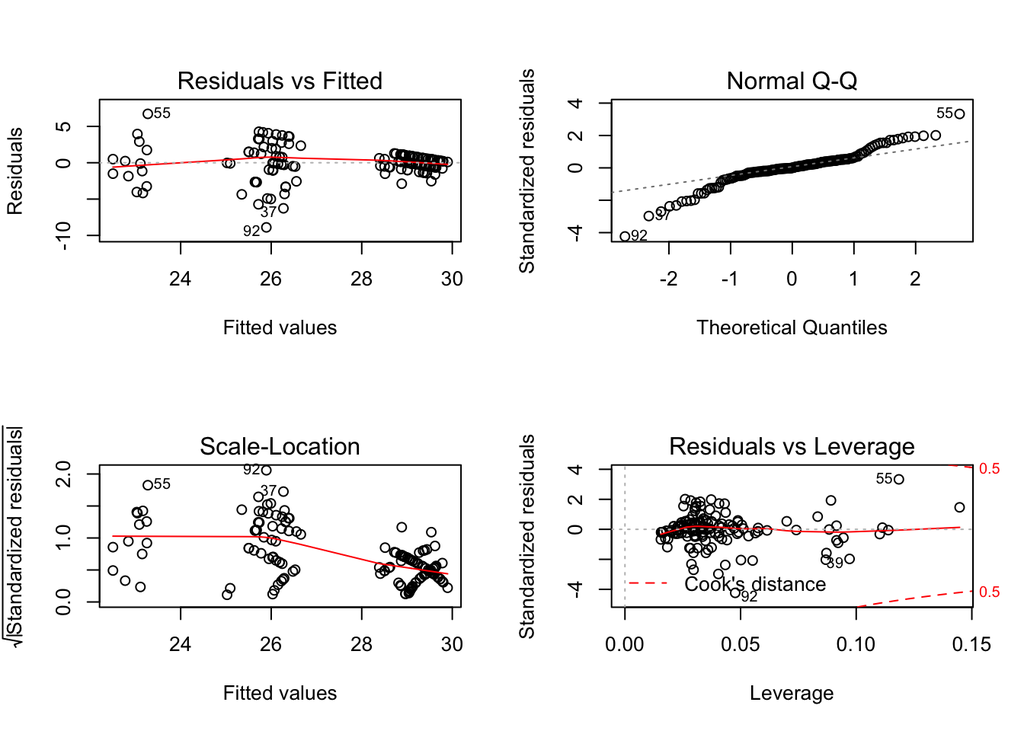

```r
par(mfrow = c(2,2)) # Change the panel layout to 2 x 2
plot(model)
```

#### Result table

```r
summary(model)
```

```
##
## Call:
## lm(formula = MMSE ~ Age + Sex + Education + relevel(factor(CDR,
##     ordered = FALSE), ref = "no dementia"), data = df_baseline)
##
## Residuals:
##     Min      1Q  Median      3Q     Max
## -8.8931 -0.6189  0.0035  0.9343  6.7251
##
## Coefficients:
##                                                                        Estimate
## (Intercept)                                                            29.73860
## Age                                                                    -0.01940
## SexM                                                                   -0.56430
## Education                                                               0.07345
## relevel(factor(CDR, ordered = FALSE), ref = "no dementia")very mild AD -2.96005
## relevel(factor(CDR, ordered = FALSE), ref = "no dementia")mild AD      -6.03833
##                                                                        Std. Error
## (Intercept)                                                               2.11330
## Age                                                                       0.02351
## SexM                                                                      0.37351
## Education                                                                 0.06457
## relevel(factor(CDR, ordered = FALSE), ref = "no dementia")very mild AD    0.41061
## relevel(factor(CDR, ordered = FALSE), ref = "no dementia")mild AD         0.64892
##                                                                        t value
## (Intercept)                                                             14.072
## Age                                                                     -0.825
## SexM                                                                    -1.511
## Education                                                                1.137
## relevel(factor(CDR, ordered = FALSE), ref = "no dementia")very mild AD  -7.209
## relevel(factor(CDR, ordered = FALSE), ref = "no dementia")mild AD       -9.305
##                                                                        Pr(>|t|)
## (Intercept)                                                             < 2e-16
## Age                                                                       0.411
## SexM                                                                      0.133
## Education                                                                 0.257
## relevel(factor(CDR, ordered = FALSE), ref = "no dementia")very mild AD 2.93e-11
## relevel(factor(CDR, ordered = FALSE), ref = "no dementia")mild AD       < 2e-16
##
## (Intercept)                                                            ***
## Age
## SexM
## Education
## relevel(factor(CDR, ordered = FALSE), ref = "no dementia")very mild AD ***
## relevel(factor(CDR, ordered = FALSE), ref = "no dementia")mild AD      ***
## ---
## Signif. codes:  0 '***' 0.001 '**' 0.01 '*' 0.05 '.' 0.1 ' ' 1
##
## Residual standard error: 2.151 on 144 degrees of freedom
## Multiple R-squared:  0.4925, Adjusted R-squared:  0.4749
## F-statistic: 27.95 on 5 and 144 DF,  p-value: < 2.2e-16
```

## References R session information

```r
citation()
```

```
##
##
##   R Core Team (2020). R: A language and environment for statistical
##   computing. R Foundation for Statistical Computing, Vienna, Austria.
##   URL https://www.R-project.org/.
##
## A BibTeX entry for LaTeX users is
##
##   @Manual{,
##     title = {R: A Language and Environment for Statistical Computing},
##     author = {{R Core Team}},
##     organization = {R Foundation for Statistical Computing},
##     address = {Vienna, Austria},
##     year = {2020},
##     url = {https://www.R-project.org/},
##   }
##
## We have invested a lot of time and effort in creating R, please cite it
## when using it for data analysis. See also 'citation("pkgname")' for
## citing R packages.
```

```r
lapply(list.of.packages, citation)
```

```
## [[1]]
##
##
##   Thomas Lin Pedersen (2020). patchwork: The Composer of Plots. R
##   package version 1.1.1. https://CRAN.R-project.org/package=patchwork
##
## A BibTeX entry for LaTeX users is
##
##   @Manual{,
##     title = {patchwork: The Composer of Plots},
##     author = {Thomas Lin Pedersen},
##     year = {2020},
##     note = {R package version 1.1.1},
##     url = {https://CRAN.R-project.org/package=patchwork},
##   }
##
##
## [[2]]
##
##
##   Alboukadel Kassambara (2020). ggpubr: 'ggplot2' Based Publication
##   Ready Plots. R package version 0.4.0.
##   https://CRAN.R-project.org/package=ggpubr
##
## A BibTeX entry for LaTeX users is
##
##   @Manual{,
##     title = {ggpubr: 'ggplot2' Based Publication Ready Plots},
##     author = {Alboukadel Kassambara},
##     year = {2020},
##     note = {R package version 0.4.0},
##     url = {https://CRAN.R-project.org/package=ggpubr},
##   }
##
##
## [[3]]
##
##   Wickham et al., (2019). Welcome to the tidyverse. Journal of Open
##   Source Software, 4(43), 1686, https://doi.org/10.21105/joss.01686
##
```

[output cut: 172 more lines]

```
##   Kazuki Yoshida and Alexander Bartel (2020). tableone: Create 'Table
##   1' to Describe Baseline Characteristics with or without Propensity
##   Score Weights. R package version 0.12.0.
##   https://CRAN.R-project.org/package=tableone
##
## A BibTeX entry for LaTeX users is
##
##   @Manual{,
##     title = {tableone: Create 'Table 1' to Describe Baseline Characteristics with or
## without Propensity Score Weights},
##     author = {Kazuki Yoshida and Alexander Bartel},
##     year = {2020},
##     note = {R package version 0.12.0},
##     url = {https://CRAN.R-project.org/package=tableone},
##   }
```

```r
#RStudio.Version()[-2] #both functions are not working in
#rstudioapi::versionInfo()[-2]
## both functions for the R Studio version are not working in R markdown. Run this code in the console and enter information manually.
```

To cite RStudio in publications use: RStudio Team (2019). RStudio: Integrated Development for R. RStudio, Inc., Boston, MA URL http://www.rstudio.com/.version Version: 1.2.5033 Release name: “Orange Blossom”